# How to setup Git(hub) in RStudio – an annotated image series

Sebastian Sauer

2019-05-22

There are many reasons to do version control. One is to allow Future You to understand what today’s You did.

[figure not shown]

OK, it may help to like technology stuff. Some say, version control really makes sense only for larger projects (say, writing your thesis) or developing in a team. Software development practically always benefits from version control.

[figure not shown]

If you don’t like memes and image-ladden stories, be warned, this post is not for you. And, it’s an opinionated approach.

All right, [welcome to the rumble](https://www.youtube.com/watch?v=XagmBjT-j08).

ID

What.do.to

image

Links

1

Install git on your machine

https://git-scm.com/book/en/v2/Getting-Started-Installing-Git

2

Register a (free) Github account

[figure not shown]

https://github.com/join?source=header

3

Introduce yourself to git

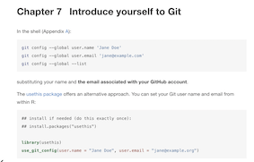

https://happygitwithr.com/hello-git.html#hello-git

4

Read the book (if you have two weeks spare time)

[figure not shown]

https://git-scm.com/book/en/v2

5

Read this book (if you have two hours spare time)

[figure not shown]

https://happygitwithr.com/

6

Read this capter (if you have ten minutes spare time)

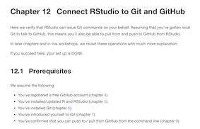

https://happygitwithr.com/rstudio-git-github.html

7

Testdrive your Github account

[figure not shown]

https://happygitwithr.com/push-pull-github.html#push-pull-github

8

Go to RStudio, Choose *File > New Project > Version Control*

[figure not shown]

https://happygitwithr.com/rstudio-git-github.html#clone-the-new-github-repository-to-your-computer-via-rstudio

9

Paste the URL of the Github repository you want to sync to your computer, eg., git@github.com:Bia-Ka/StudentGuide2R.git

[figure not shown]

https://happygitwithr.com/rstudio-git-github.html

One advise ….

[figure not shown]